# Hands-on RMarkdown session

Let’s learn and practice!

Ieva Rauluseviciute

Date: 2023-11-16

# Introduction

RMarkdown is a very useful thing to learn and it can help you:

- make a nice report on your analysis;
- create a reproducible workflow;
- make a tutorial (just like this one);
- make organized notes when executing code.

In this document I will not list all the syntax or other functionalities of RMarkdown, because this was already covered or there are plenty of recourses online (see bolow). Here we will try to write and execute code.

```r
rmarkdown::render(
    "/home/ievarau/Documents/phd/software_quality_seminars/rmarkdown_hands-on/hands_on.Rmd",
    output_format = "html_document")
# rmarkdown::render("input.Rmd", html_document(toc = TRUE, toc_depth = 2))
```

## RMarkdown cheatsheet

RStudio (or now Posit) offers a collection of [**cheatsheets**](https://posit.co/resources/cheatsheets/) that I highly recommend. One of them is for [**RMarkdown**](https://rstudio.github.io/cheatsheets/html/rmarkdown.html).

## Other recources

Basic RMarkdown syntax was covered in Software quality session. There are some recources available.

- [this GIT repo](https://github.com/ievarau/software_quality_seminars/tree/main/rmarkdown) with the template document, examples and explanations. It has it’s accompanying SoftFlix [episode](https://drive.google.com/drive/folders/1OvV3Ajw39mYW30ZIeHJmCSfUDk_sPFfy)
- Some other topics were covered using RMarkdown. For example [more advanced ggplot2 plotting session](https://github.com/ievarau/software_quality_seminars/tree/main/ggplot_advanced_plotting_part1).

# Load your libraries

Let’s load libraries.

```r
required.libraries <- c("cowplot",
                        "data.table",
                        "ggplot2",
                        "tidyverse",
                        "png",
                        "ggseqlogo",
                        "ggrepel",
                        "downloadthis")

for (lib in required.libraries) {
    suppressPackageStartupMessages(library(lib, character.only = TRUE, quietly = T))
}
```

# Get your data

```r
## Conservation files:
cons_file        <- "example_data/CTCF_conservation.tsv"
random_cons_file <- "example_data/CTCF_conservation_random.tsv"

## Motifs:
cobinder_file <- "example_data/cobinder_0.txt"
core_file     <- "example_data/core_0.txt"

## Motif grammar:
location <- "left"
spacing  <- "13"
```

# Read your data

```r
## Conservation files:
cons   <- data.table::fread(cons_file, header = FALSE)
random <- data.table::fread(random_cons_file, header = FALSE)

df   <- cbind(cons, random[,2])
colnames(df) <- c("dist", "Observed", "Random")

df <- df %>%
    dplyr::select(dist, Observed, Random) %>%
    gather(key = "Track", value = "value", -dist)

## Motif files:
cobinder_matrix <- data.table::fread(cobinder_file, header = FALSE)
core_matrix     <- data.table::fread(core_file, header = FALSE)
```

## Conservation data

| dist | Track | value |
| --- | --- | --- |
| -50 | Observed | 0.0936913863428646 |
| -49 | Observed | 0.0909354454889672 |
| -48 | Observed | 0.0924131506724115 |
| -47 | Observed | 0.0926600061365714 |
| -46 | Observed | 0.0898711945423685 |
| -45 | Observed | 0.0882283134874004 |
| -44 | Observed | 0.088307860033947 |
| -43 | Observed | 0.0866163440396919 |
| -42 | Observed | 0.0869411115028072 |
| -41 | Observed | 0.089768175218697 |

[output cut: 190 more lines]

**Table 1. Conservation data**. Example table with real observations

## Input motifs

### COBINDER

| A | C | G | T |
| --- | --- | --- | --- |
| 0.094864 | 0.678042 | 0.146154 | 0.080939 |
| 0.075112 | 0.058105 | 0.022355 | 0.844428 |
| 0.009346 | 0.004730 | 0.978529 | 0.007395 |
| 0.016712 | 0.881151 | 0.008995 | 0.093142 |
| 0.797858 | 0.053923 | 0.044679 | 0.103540 |
| 0.188077 | 0.130577 | 0.617423 | 0.063923 |
| 0.044777 | 0.113988 | 0.043025 | 0.798210 |

### CORE

| A | C | G | T |
| --- | --- | --- | --- |
| 0.732149 | 0.032847 | 0.127672 | 0.107333 |
| 0.043005 | 0.576965 | 0.352729 | 0.027301 |
| 0.154035 | 0.437185 | 0.076371 | 0.332409 |
| 0.834983 | 0.028972 | 0.087093 | 0.048952 |
| 0.011696 | 0.002182 | 0.982426 | 0.003696 |
| 0.419504 | 0.003289 | 0.571785 | 0.005421 |
| 0.039622 | 0.021761 | 0.524714 | 0.413903 |
| 0.020478 | 0.004265 | 0.966948 | 0.008309 |
| 0.037937 | 0.052247 | 0.825838 | 0.083978 |
| 0.128704 | 0.746734 | 0.025730 | 0.098831 |

# Plot your data

## Plotting conservation

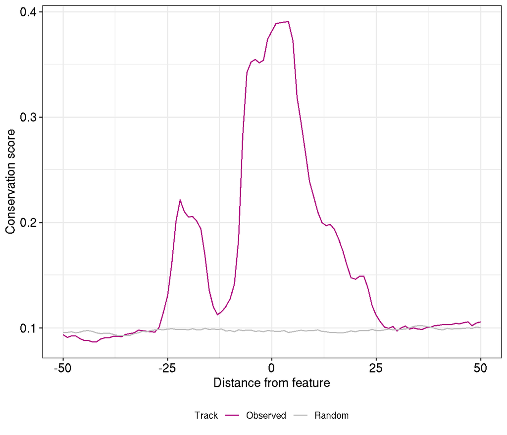

**Figure 1. Conservation plot**

```r
colors <- c("#ae017e", "#bdbdbd")

## Conservation base plot:
conservation_plot <- ggplot(
        df,
        aes(x = dist, y = value)) +
    geom_line(aes(color = Track)) +
    scale_color_manual(values = colors) +
    theme_bw() +
    xlab("Distance from feature") +
    ylab("Conservation score") +
    theme(legend.position = "bottom") +
    theme(
        plot.title = element_text(size = 14),
        axis.title = element_text(size = 16, colour = "black"),
        axis.text = element_text(size = 14, colour = "black")
    )

conservation_plot
```

```r
cobinder_size <- nrow(cobinder_matrix)
core_size     <- nrow(core_matrix)

window_size   <- nrow(random)

core_end   <- (core_size / 2)
core_start <- ((-1 * core_size) / 2)

if (location == "left") {
    spacing       <- (-1 * as.numeric(spacing))
    cobinder_size <- (-1 * cobinder_size)
}

cobinder_end   <- core_start + spacing
cobinder_start <- cobinder_end + cobinder_size

core_segment     <- data.frame(
    x    = core_start,
    xend = core_end,
    y    = 0,
    yend = 0)
cobinder_segment <- data.frame(
    x    = cobinder_start,
    xend = cobinder_end,
    y    = 0,
    yend = 0)
```

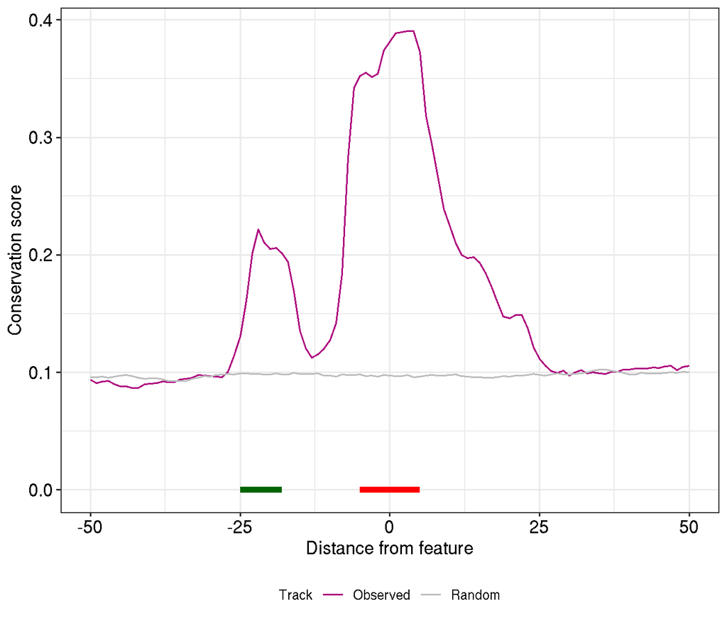

**Figure 2. Conservation plot with specified motif locations**

```r
conservation_plot <- conservation_plot +
    geom_segment(data = core_segment,
                aes(x = x, y = y, yend = yend, xend = xend),
                inherit.aes = FALSE,
                colour = "red", linewidth = 2,
                show.legend = NA) +
    geom_segment(data = cobinder_segment,
                aes(x = x, y = y, yend = yend, xend = xend),
                inherit.aes = FALSE,
                colour = "darkgreen", linewidth = 2)

conservation_plot
```

## Plotting motif logos

```r
plot_motif <- function(motif_matrix) {
    motif_logo <- ggplot() +
        geom_logo(motif_matrix, method = 'bits', stack_width = 1) +
        theme_logo() +
        scale_x_continuous(expand = c(0, 0)) +
        scale_y_continuous(limits = c(0,2), expand = c(0, 0)) +
        theme(axis.text.x = element_blank(),
                axis.title.y = element_blank(),
                axis.text.y = element_blank(),
                panel.grid = element_blank(),
                axis.line=element_blank(),
                axis.text = element_blank(),
                axis.ticks=element_blank(),
                axis.title = element_blank(),
                panel.border=element_blank(),
                panel.spacing = unit(0, "cm"),
                panel.grid.major=element_blank(),
                panel.grid.minor=element_blank(),
                plot.margin = margin(0, 0, 0, 0, "cm"))
    return(motif_logo)
}
## Cobinder matrix:
colnames(cobinder_matrix) <- c("A", "C", "G", "T")
cobinder_matrix <- t(cobinder_matrix)
cobinder_logo   <- plot_motif(cobinder_matrix)
## Core matrix:
colnames(core_matrix) <- c("A", "C", "G", "T")
core_matrix <- t(core_matrix)
core_logo   <- plot_motif(core_matrix)
```

### COBINDER logo

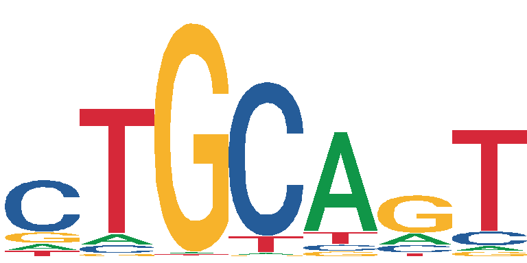

**Figure 3. Motif logos**

### CORE logo

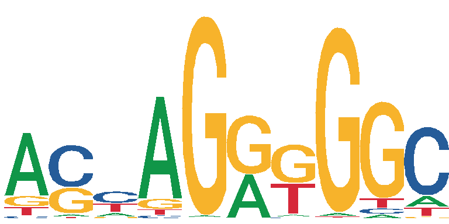

**Figure 3. Motif logos**

## Annotating conservation plot with motifs

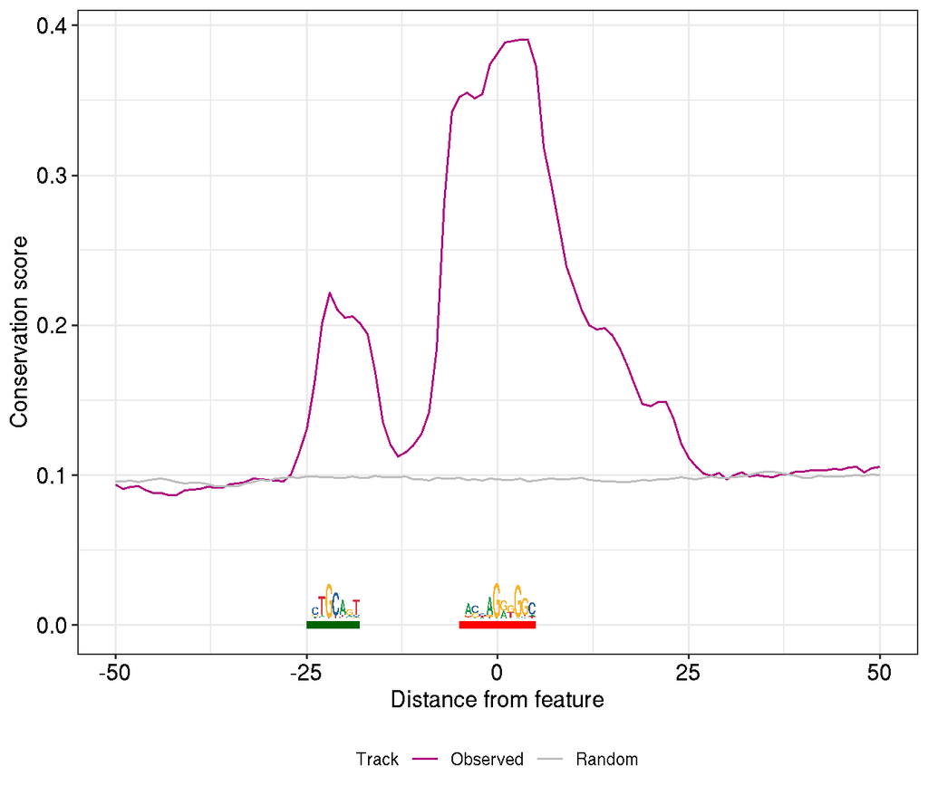

**Figure 4. Conservation plot with visualized motifs and their locations**

```r
## Adding motifs to the plot:
conservation_plot <- conservation_plot +
    annotation_custom(
        ggplotGrob(core_logo),
        xmin = core_segment$x,
        xmax = core_segment$xend,
        ymin = 0.0005,
        ymax = round(max(df$value)/12, 2)) +
    annotation_custom(
        ggplotGrob(cobinder_logo),
        xmin = cobinder_segment$x,
        xmax = cobinder_segment$xend,
        ymin = 0.0005,
        ymax = round(max(df$value)/12, 2))

conservation_plot
```

```r
## Expporting the plot:
conservation_plot_pdf <- file.path("conservation_plot_example_with_annotations.pdf")
ggsave(
    plot      = conservation_plot,
    filename  = conservation_plot_pdf,
    width     = 7,
    height    = 6,
    limitsize = FALSE)
```

# Importing and displaying results from other places

We will try to import a plot as an R object and then display it in our report.

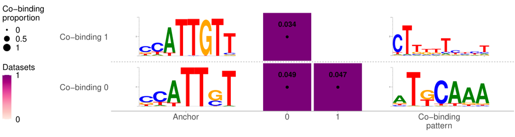

**Figure 5. Spacings plot for SOX17**

[figure not shown]

```r
path_to_example_plot <- "example_data/example_plot.RData"

spacings_plot <- get(load(path_to_example_plot))

path_to_example_plot <- "example_data/example_plot.png"

knitr::include_graphics(path_to_example_plot, dpi = 1200)
```